# COMPASScovariate Test Simulations

Tyler Schappe

2022-11-22

## Notes

Alternative sim method (prioritize this one):

1. Generate X cov
2. Specify true betas (non-zero simulated from Normal)
3. Run logistic regression to compute p-hat
4. Using p-hat, generate Gamma matrix via rbinom()
5. Generate pu, which is props for unstim
6. Generate counts via multinomial
7. Conditioned on gamma and pu, generate ps
8. Generate ns (counts) from ps (prob vector)

Using real data (COMPASS vignette):

1. Run COMPASS on real data
2. Get Gamma matrix
3. Get ns and nu (counts)
4. Generate X
5. Run logistic regression (glmnet with lasso) between gamma and X. Estimated beta will be considered “true” beta.

**Note on iterations:**

Keep only the last X iterations and use the first ones to warm up chains.

**12/13/22 To Do:**

- Create density plot of posterior for betas that have a large difference between estimated and true.
- Reduce to 2 markers = 4 cell subsets
- Modify covariates (intercept) to allow ~ 50% of gammas to be 1

### Additional Complexities

1. Smaller difference in concentration parameters between stim and unstim
2. Different number of total events and event subsets for stim and unstim samples

## Simulate Data

**Approach**

1. Matrix of true betas for each k-1 subset for each covariate p ~ Normal(beta.mu, beta.sigma)
   1. Model selection where any beta where |beta| < beta.selection.cutoff -> 0
2. Vector of true intercepts for each k-1 subset ~ Normal(int.mu, int.sd)
   1. int.mu is 0 to keep probability that gamma = 1 ~ 50%, which makes estimating betas easier.
3. Matrix X (I x p) of covariates with first column of 1’s for intercept
4. Omega (I x K1): For each sample, for each subset, generate linear predictor as linear combination of sample’s covariate values X[i,] and subset-specific true betas beta.true.final[k,]
5. gamma.m (I x K1): For each sample, for each subset, map linear predictor to probability using inverse-logit function
6. Generate unstimulated and stimulated counts from a Dirichlet-Multinomial distribution where the concentration parameters are drawn from a lognormal distribution with same logmean and logsd values.
   1. For stimulated cluster-samples (where gamma = 1), shift the logmean by ps.logmu.diff to increase the concentration parameter by exp(ps.logmu.diff).
   2. For each sample, number of stimulated and unstimulated counts ~ Normal(e.total.mu, e.total.sd). This is the total number of stim and unstim counts for each sample.
   3. For both stimluated and unstimulated, use Dirichlet-Multinomial to draw subset of stimulated and unstimulated counts ~ Normal(e.mu, e.sd). This is the number of stim and unstim counts for all K subsets. **Note:** The values of the concentration parameter can be interpreted as prior pseudo-counts and thus determine the variance among categories. Use high concentration parameter values to reduce the variance in counts among categories in resulting draws.
   4. **Important:** The Kth category is included in the draws, but has a very large concentration parameter compared to rest of the categories so that the number of counts is much larger. This is to mimic real flow data where the majority of cells are in the “all negative” subset (ie. they don’t belong to any of the mutually exclusive categories created by the markers of interest). We include this category because otherwise additional counts for a stimulated cell subset take away counts from only the k - 1 markers, resulting in significantly reduced counts for them (Lynn’s original method). Here, the counts for the stimulated cell subset are “taken” from all other subsets with probability proportionate to the concentration parameters. Since the kth subset is given such a high concentration, it is much more likely that the counts are “taken” from that category, thus allowing the counts for the k - 1 subsets to remain constant (with some noise) between unstim and stim samples if they are not truely stimulated.

### Set Fixed Parameters

```r
set.seed(111)

I <- 100 ## sample size i.e., #subjects
K <- 4 ## number of cell categories
K1 = K-1 ## number of cell categories minus one (last one is baseline)
p <- 5 # number of covariates # larger p
e.total.mu = 10000 #Mean total number of events per subject
e.total.sd = 10   #SD of total number of events per subject
e.subset.mu = 3000 #Mean number of events per subject that are not in the Kth category (all negative set)
e.subset.sd = 5   #SD of number of events per subject that are not in the Kth category (all negative set)

#Betas
beta.mu = 0
beta.sigma = 0.8
int.mu = 0
int.sd = 0.1
beta.selection.cutoff = 0.2

### Pu and Ps
#Concentration params drawn from lognormal
pu.logmu = log(20)
p.logsd = 0.01
ps.logmu.diff = log(5)

### COMPASScovariate
iter = 8000
rep = 2

#Figure output
fig.out.dir = file.path("/work",
                        Sys.getenv("USER"),
                        "COMPASScovariate-sim",
                        "output",
                        "figures"
)
dir.create(fig.out.dir,
           showWarnings = FALSE,
           recursive = TRUE
)
```

### True Regression Coefs

Set true betas

```r
#Intercepts
int.true = rnorm(n = K1,
                 mean = int.mu,
                 sd = int.sd
                 )

#Covariate betas
beta.true = matrix(rnorm(n = K1*(p),
                         mean = beta.mu,
                         sd = beta.sigma),
                   nrow = K1
                  )
```

```r
beta.true.selection = apply(beta.true, MARGIN = c(1,2), FUN = function(x) ifelse(abs(x) < beta.selection.cutoff, 0, x))
```

Bind intercept betas to other betas

```r
beta.true.final <- cbind(int.true, beta.true.selection)
```

Make covariates

```r
X <- cbind(
      #First column is 1s for intercept
      rep(1, I*1),
      #Remainder are for covariates
      matrix(rnorm(n = I*p),
            ncol = p,
            nrow = I
      )
)
```

### True Gamma Matrix

Generate omega_ik – probability that gamma_ik = 1

1. p covariates from subject i x betas for p coefficients for cluster k gives linear predictor for cluster k in subject i
2. Inverse-logit transform linear predictor to obtain prob that gamma = 1 (true diff between stim and unstim) for cluster k in subject i

```r
#Empty matrix to hold omega
omega <- matrix(NA,
                nrow = I,
                ncol = K1
                )

#Empty matrix to hold gamma
gamma.m <- matrix(NA,
                     nrow = I,
                     ncol = K1
                     )

for (i in 1:I) {
  for (k in 1:K1) {
    #Generate linear predictor and prob via inverse link
    omega[i,k] <- binomial()$linkinv(X[i, ] %*% beta.true.final[k,]) #p covariates from ith subject x betas for p coefficients for kth cluster gives linear predictor

    #Generate gamma as Bernoulli RV with probs from omega
    gamma.m[i,k] <- rbinom(n = 1,
                           size = 1,
                           prob = omega[i,k]
                           )
  }
}
```

Check proportion = 1

```r
round(sum(gamma.m) / length(gamma.m), 3)
```

```
[1] 0.483
```

### True Counts

Empty matrices for stim and unstim counts. **Note:** Create K columns with 0s, not K - 1

```r
n_u <- matrix(0,
              nrow = I,
              ncol = K)

n_s <- matrix(0,
              nrow = I,
              ncol = K)
```

#### Unstimulated

Generate unstimulated count values for each subject

```r
#Generate total counts
Nu = ceiling(
      rnorm(mean = e.total.mu,
            sd = e.total.sd,
            n = I)
)

Nu.subset = ceiling(
              rnorm(mean = e.subset.mu,
                    sd = e.subset.sd,
                    n = I
              )
)
```

**Notes:**

```r
concentration_u = matrix(NA,
                         nrow = I,
                         ncol = K
                  )

for (i in 1:I) {
  concentration_u[i,1:K1] = rlnorm(n = K1,
                 meanlog = (pu.logmu),
                 sdlog = p.logsd
  )

  concentration_u[i,K] = rlnorm(n = 1,
                                meanlog = pu.logmu*3,
                                sdlog = p.logsd
  )
  #HMP version
  n_u[i,1:K] = t(matrix(HMP::Dirichlet.multinomial(Nrs = Nu[i], shape = concentration_u[i,])))

  # #MultiRNG version
  # n_u[i,1:K] = MultiRNG::draw.dirichlet.multinomial(N = Nu[i],                    #Total counts
  #                                                        no.row = 1,                      #Sample size
  #                                                        d = length(concentration_u[i,]), #Number of categories (same as length of concentration vector)
  #                                                        alpha = concentration_u[i,],     #Concentration vector
  #                                                        beta = 1                         #Common shape parameter
  #                                                             )
}
```

Check rowsums

```r
identical(rowSums(n_u), Nu)
```

```
[1] TRUE
```

#### Stimulated

Generate stimulated count values for each subject

```r
#Generate total counts
Ns = ceiling(
      rnorm(mean = e.total.mu,
            sd = e.total.sd,
            n = I)
)

Ns.subset = ceiling(
              rnorm(mean = e.subset.mu,
                    sd = e.subset.sd,
                    n = I
              )
)
```

**Notes:**

```r
concentration_s = matrix(NA,
                         nrow = I,
                         ncol = K
                  )

for (i in 1:I) {
  concentration_s[i, 1:K1] = rlnorm(n = K1,
                 meanlog = (pu.logmu + ps.logmu.diff * gamma.m[i, ]),
                 sdlog = p.logsd
  )

  concentration_s[i, K] = rlnorm(n = 1,
                                meanlog = pu.logmu*3,
                                sdlog = p.logsd
  )
  #HMP version
  n_s[i,1:K] = t(matrix(HMP::Dirichlet.multinomial(Nrs = Ns[i], shape = concentration_s[i,])))

  # #MultiRNG version
  # n_s[i,1:K] = MultiRNG::draw.dirichlet.multinomial(N = Ns[i],                #Total counts
  #                                                    no.row = 1,                      #Sample size
  #                                                    d = length(concentration_s[i,]), #Number of categories (same as length of concentration vector)
  #                                                    alpha = concentration_s[i,],     #Concentration vector
  #                                                    beta = 1                         #Common shape parameter
  #                                                             )
}
```

Check rowsums

```r
identical(rowSums(n_s), Ns)
```

```
[1] TRUE
```

Check that rowsums are similar for sample sample between unstim and stim

```r
rowSums(n_u)[1:10]
```

```
 [1] 10009 10010 10008  9999 10008  9998 10015 10000  9993  9987
```

```r
rowSums(n_s)[1:10]
```

```
 [1] 10012 10010  9982 10000 10010 10008 10001 10002 10010  9991
```

## Run COMPASScovariate

Create a version of X without an intercept column

```r
X.mod = X[,-1]
```

```r
sim.fit = .COMPASS.covariate(n_s = n_s,
                             n_u = n_u,
                             X = X.mod,
                             iterations = iter,
                             replication = rep)
```

```
Initializing parameters...
Computing initial parameter estimates...
Iteration 1000 of 8000.
Iteration 2000 of 8000.
Iteration 3000 of 8000.
Iteration 4000 of 8000.
Iteration 5000 of 8000.
Iteration 6000 of 8000.
Iteration 7000 of 8000.
Iteration 8000 of 8000.
Fitting model with 2 replications.
Running replication 1 of 2...
Iteration 1000 of 8000.
Iteration 2000 of 8000.
Iteration 3000 of 8000.
Iteration 4000 of 8000.
Iteration 5000 of 8000.
Iteration 6000 of 8000.
Iteration 7000 of 8000.
Iteration 8000 of 8000.
Running replication 2 of 2...
Iteration 1000 of 8000.
Iteration 2000 of 8000.
Iteration 3000 of 8000.
Iteration 4000 of 8000.
Iteration 5000 of 8000.
Iteration 6000 of 8000.
Iteration 7000 of 8000.
Iteration 8000 of 8000.
Done!
```

## Compare Estimates to True

Create a custom function for calculating the mode

```r
getmode <- function(v) {
   uniqv <- unique(v)
   uniqv[which.max(tabulate(match(v, uniqv)))]
}
```

### Gamma

```r
sim.fit$mean_gamma[1:4,]
```

```
     [,1] [,2] [,3] [,4]
[1,]    1    0    0    1
[2,]    1    1    1    1
[3,]    0    0    0    0
[4,]    0    0    1    1
```

```r
sim.fit.gamma <- apply(sim.fit$gamma, MARGIN = c(1,2), FUN = function(x) getmode(x))

sim.fit.gamma[1:4,]
```

```
     [,1] [,2] [,3] [,4]
[1,]    1    0    0    1
[2,]    1    1    1    1
[3,]    0    0    0    0
[4,]    0    0    1    1
```

```r
gamma.m[1:4,]
```

```
     [,1] [,2] [,3]
[1,]    1    0    0
[2,]    1    1    1
[3,]    0    0    0
[4,]    0    0    1
```

```r
n_u[1:4,]
```

```
     [,1] [,2] [,3] [,4]
[1,]   19   26   31 9933
[2,]   19   29   25 9937
[3,]   17   27   14 9950
[4,]   29   29   58 9883
```

```r
n_s[1:4,]
```

```
     [,1] [,2] [,3] [,4]
[1,]  129   13   11 9859
[2,]  123  145  127 9615
[3,]   27   10   30 9915
[4,]   35   20  124 9821
```

#### Percentage Correct

```r
print(
  paste(
    "Percent gamma correct (excluding Kth subset):",
    round(
      sum(gamma.m == sim.fit.gamma[,-ncol(sim.fit.gamma)]) /
        (dim(gamma.m)[1] * dim(gamma.m)[2]) * 100,
      digits = 2
    )
  )
)
```

```
[1] "Percent gamma correct (excluding Kth subset): 100"
```

### Betas

```r
sim.fit.beta.median <- apply(sim.fit$beta, MARGIN = c(1,2), FUN = function(x) median(x))

sim.fit.beta.median
```

```
           [,1]        [,2]       [,3]        [,4]      [,5]       [,6]
[1,] -0.3451861 -3.31714234 -1.2364779 -0.77103658 1.7518562 -1.9481025
[2,]  0.1899554  0.05772461 -0.6953482 -0.03622254 0.2196795 -0.0163293
[3,] -0.3594646 -0.07826367 -0.5982247 -0.24497622 0.8869008 -0.3134904
```

```r
beta.true.final
```

```
        int.true
[1,]  0.02352207 -1.841877 -1.1979413 -0.3951698 1.4765090 -1.2533323
[2,] -0.03307359  0.000000 -0.8081507  0.0000000 0.3152433  0.0000000
[3,] -0.03116238  0.000000 -0.7587805 -0.3252790 0.6380228 -0.2873116
```

#### 95% Interval Coverage

Find 95% quantile intervals for each beta

```r
lower.95 <- apply(sim.fit$beta, MARGIN = c(1,2), FUN = function(x) quantile(x,
                                                                 prob = 0.025
                                                                 )
      )

upper.95 <- apply(sim.fit$beta, MARGIN = c(1,2), FUN = function(x) quantile(x,
                                                                 prob = 0.975
                                                                 )
      )
```

Find percentage of true values outside of 95% quantile interval

```r
beta.coverage <- beta.true.final >= lower.95 & beta.true.final <= upper.95

print(
  paste(
    "Percent true betas within 95% quantile interval:",
    round(
      sum(
        beta.coverage
      ) / length(beta.true.final) * 100,
      2
    )
  )
)
```

```
[1] "Percent true betas within 95% quantile interval: 94.44"
```

#### Plot All Betas

1. Extract beta draws into a dataframe with cluster and covariate indicators
2. Row-bind together into long format
3. Plot with x as cluster and y as covariate

Extract beta draws into a dataframe with cluster and covariate indicators

```r
cov.out <- list(NULL)
cluster.out <- list(NULL)

#Loop over each k-1 cluster
for (k in 1:K1) {
  #Extract a matrix of draws x coefficients for current cluster
  cluster <- t(apply(sim.fit$beta, MARGIN = c(2,3), FUN = function(x) x[k]))

  #Make a dataframe for each covariate (column) with current cluster and covariate ID
  for (cov in 1:(p+1)) { #p+1 b/c of intercept
    cov.out[[cov]] <-
      data.frame(cluster = k,
               covariate = cov,
               value = apply(cluster, MARGIN = 1, FUN = function(y) y[cov])
    )
  }

  #Combine the dataframes for each coefficient for the current cluster
  cluster.out[[k]] <- do.call('rbind', cov.out)
}

#Combine the dataframes for all clusters
post.out <- do.call('rbind', cluster.out)
```

Check that rows of post.out match dimension of original beta draws

```r
dim(post.out)[1] ==
  dim(sim.fit$beta)[1] * (dim(sim.fit$beta)[2]) * dim(sim.fit$beta)[3]
```

```
[1] TRUE
```

Make cluster and covariate factors

```r
post.out$cluster <- as.factor(post.out$cluster)
post.out$covariate <- as.factor(post.out$covariate)
```

Include true betas

```r
post.out$true.beta <- NA

for (k in 1:K1) {
  for (cov in 1:(p+1)) {
    post.out$true.beta[post.out$cluster == k & post.out$covariate == cov] <- beta.true.final[k,cov]
  }
}

#Check that length of unique true.beta is equal to number of true betas
(
#Number of unique betas excluding duplicated 0s
length(unique(post.out$true.beta)) +
  #Number of cluster-covariate combinations where true.beta is 0 minus 1 (b/c 1 true 0 already counted above)
  length(unique(paste(post.out$cluster[post.out$true.beta == 0], post.out$covariate[post.out$true.beta == 0]))) - 1
) ==
  #Equal to dimension of true beta (without intercept?)
  length(beta.true.final)
```

```
[1] TRUE
```

Make the plot

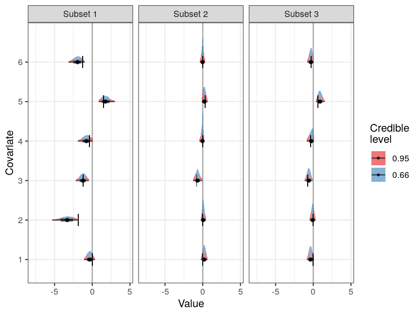

```r
#Mapping nice cluster names
cluster_names <- c(
  "1" = "Subset 1",
  "2" = "Subset 2",
  "3" = "Subset 3"
)

beta.post.true.plot <-
  ggplot(data = post.out,
         aes(y = covariate, x = value)
    )+
    geom_vline(xintercept = 0,
               size = 0.6,
               color = "dark gray"
    )+
    tidybayes::stat_halfeye(aes(fill = stat(level)),
                            fatten_point = 0.85,
                            alpha = 0.6
    ) +
    geom_segment(
                 aes(x = true.beta,
                     y = as.integer(covariate) - 0.15,
                     yend = as.integer(covariate) + 0.15,
                     xend = true.beta
                  ),
                 size = 0.2
    )+
    facet_wrap(~ cluster,
               labeller = labeller(
                 cluster = cluster_names
               )
    )+
    theme_bw()+
    xlab("Value")+
    ylab("Covariate")+
    scale_fill_brewer(name = "Credible\nlevel",
                      na.translate = FALSE,
                      palette = "Set1",
    )

beta.post.true.plot
```

```r
ggsave(beta.post.true.plot,
       filename = file.path(fig.out.dir,
                            "beta.post.true.plot.pdf"
                            ),
       width = 6,
       height = 4
       )
```

#### Plot Posteriors Not Achieving Coverage

```r
#Loop over rows of beta.diff and find row,col of estimates that fail to achieve coverage
beta.no.cover.coord <- list(NULL)
for (i in 1:nrow(beta.coverage)) {
  if(length(which(beta.coverage[i,] == FALSE)) > 0) {
    #Paste the row name (i) with the indices of the columns for the current row
    beta.no.cover.coord[[i]] <- paste(i, which(beta.coverage[i,] == FALSE), sep = ", ")
  } else {
    beta.no.cover.coord[[i]] <- NULL
  }
}

beta.no.cover.coord.df <- do.call('c', beta.no.cover.coord)
```

Extract and plot posterior samples for flagged coefs (if any)

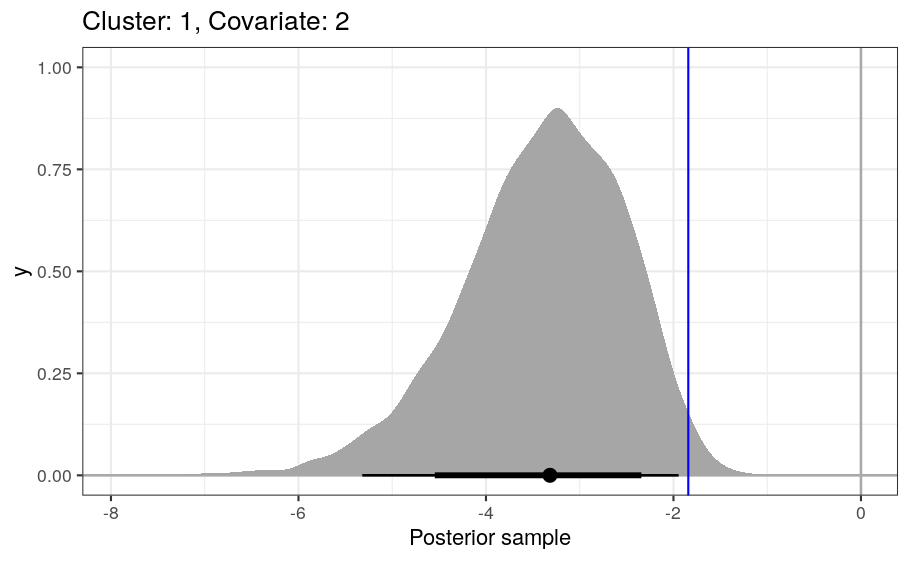

```r
if (length(beta.no.cover.coord.df) > 0) {
  lapply(1:length(beta.no.cover.coord.df), FUN = function(i) {
    #Extract the posterior samples for the current beta
    post <- data.frame(samples = eval(parse(text = paste0("sim.fit$beta",
                             "[",
                             beta.no.cover.coord.df[i],
                             ",]"
                             )
                                           )
                                     )
         )

    #Extract the true beta value
    true.beta <- eval(parse(text = paste0("beta.true.final",
                           "[",
                           beta.no.cover.coord.df[i],
                           "]"
                                     )
                       )
                 )

    #Make the plot
    ggplot(data = post,
           aes(x = samples)
      )+
      theme_bw()+
      geom_vline(xintercept = 0,
                 size = 0.6,
                 color = "dark gray"
      )+
      geom_hline(yintercept = 0,
                 size = 0.6,
                 color = "dark gray"
      )+
      ggdist::stat_halfeye(
        .width = c(0.95, 0.8),
        point_interval = "median_qi"    #Use median for point est
      )+
      geom_vline(xintercept = true.beta,
                 color = "blue"
      )+
      xlab("Posterior sample")+
      labs(title = paste0("Cluster: ",
                  stringr::str_split(beta.no.cover.coord.df[i],
                                     pattern = ", ",
                                     simplify = TRUE
                  )[1],
                  ", Covariate: ",
                  stringr::str_split(beta.no.cover.coord.df[i],
                                     pattern = ", ",
                                     simplify = TRUE
                  )[2]
                  )
      )
  })
}
```